# PML-Assignment-Writeup

Jonathan Isernhagen

December 26, 2015

### Synopsis

We have been asked to analyze a data set of metrics related to the performance of weight-lifting physical exercises, with each corresponding to: A) a properly-performed exercise, or; B-E) an exercise improperly-performed in a specific way. Our task is to use any and all useful metrics to ascertain which category “bucket” of correct or incorrect exercise each observation belongs to, and predict the A-E category for a set of twenty new observations with the highest possible degree of accuracy. Our preference in this context is for accuracy over interpretability or scalability.

### Executive Summary

After deleting all variables which contained few or no values in order to concentrate the algorithms’ efforts on useful data of manageable size, and creating a simple random forest model with no preprocessing of the data and a simple 60/40 split of the data into testing/training (with no cross-validation, boosting or bootstrapping) we discovered a model which gave us very high accuracy on both the training and testing data sets and perfect (100%) accuracy on the validation set.

### Analyses

**Exploratory Analysis:**

We first installed the caret package, ggplot2 for charting and dplyr for data manipulation, then imported the “training” (which we labeled as training.and.testing) and “testing” (which we labeled “validation”) data sets.

```r
require(caret); require(randomForest); require(ggplot2); require(dplyr)
training.and.testing<-read.csv("pml-training.csv")
validation<-read.csv("pml-testing.csv")
```

```r
training.and.testing.cut<-select(training.and.testing, new_window:total_accel_belt, gyros_belt_x:total_accel_arm, gyros_arm_x:magnet_arm_z, roll_dumbbell:yaw_dumbbell, total_accel_dumbbell, gyros_dumbbell_x:yaw_forearm, total_accel_forearm, gyros_forearm_x:magnet_forearm_z, classe)
validation.cut<-select(validation, new_window:total_accel_belt, gyros_belt_x:total_accel_arm, gyros_arm_x:magnet_arm_z, roll_dumbbell:yaw_dumbbell, total_accel_dumbbell, gyros_dumbbell_x:yaw_forearm, total_accel_forearm, gyros_forearm_x:magnet_forearm_z)
validation.cut$magnet_forearm_y<-as.numeric(validation.cut$magnet_forearm_y)
validation.cut$magnet_forearm_z<-as.numeric(validation.cut$magnet_forearm_z)
levels(validation.cut$new_window) <- c("no", "yes")
```

We then divided the “training.and.testing” data set into “training” and “testing” partitions.

```r
inTrain<-createDataPartition(y=training.and.testing.cut$classe, p = 0.6, list = FALSE)
training<-training.and.testing.cut[inTrain,]
testing<-training.and.testing.cut[-inTrain,]
```

**Model #1: random forest, no preprocessing, 60/40 split:** Our first model was a simple random forest. Evoking the random forest from within caret (modelFit<-train(classe ~ ., data = training, method=“rf”)) took too long, so we did it directly.

```r
set.seed(1)
modelFit<-randomForest(classe ~ ., data = training)
modelFit
```

```
##
## Call:
##  randomForest(formula = classe ~ ., data = training)
##                Type of random forest: classification
##                      Number of trees: 500
## No. of variables tried at each split: 7
##
##         OOB estimate of  error rate: 0.4%
## Confusion matrix:
##      A    B    C    D    E  class.error
## A 3347    0    0    0    1 0.0002986858
## B    4 2274    1    0    0 0.0021939447
## C    0   15 2039    0    0 0.0073028238
## D    0    0   20 1909    1 0.0108808290
## E    0    0    0    5 2160 0.0023094688
```

```r
predictions<-predict(modelFit, newdata=testing)
confusionMatrix(predictions, testing$classe)
```

```
## Confusion Matrix and Statistics
##
##           Reference
## Prediction    A    B    C    D    E
##          A 2230    0    0    0    0
##          B    2 1517   10    0    0
##          C    0    1 1358    8    0
##          D    0    0    0 1277    7
##          E    0    0    0    1 1435
##
## Overall Statistics
##
##                Accuracy : 0.9963
##                  95% CI : (0.9947, 0.9975)
##     No Information Rate : 0.2845
##     P-Value [Acc > NIR] : < 2.2e-16
##
##                   Kappa : 0.9953
##  Mcnemar's Test P-Value : NA
##
## Statistics by Class:
##
##                      Class: A Class: B Class: C Class: D Class: E
## Sensitivity            0.9991   0.9993   0.9927   0.9930   0.9951
## Specificity            1.0000   0.9981   0.9986   0.9989   0.9998
## Pos Pred Value         1.0000   0.9922   0.9934   0.9945   0.9993
## Neg Pred Value         0.9996   0.9998   0.9985   0.9986   0.9989
## Prevalence             0.2845   0.1935   0.1744   0.1639   0.1838
## Detection Rate         0.2842   0.1933   0.1731   0.1628   0.1829
## Detection Prevalence   0.2842   0.1949   0.1742   0.1637   0.1830
## Balanced Accuracy      0.9996   0.9987   0.9957   0.9960   0.9975
```

…which showed an encouragingly very low error rate (we expected the testing error rate to be significantly higher than the training error rate because of overfitting), and gave us the confidence to proceed directly to the validation phase and use one of our two submission “bullets” to see if the model was in fact highly predictive.

The predictions achieved when applying the model to the validation set were as follows:

```r
predictions<-predict(modelFit, newdata=validation.cut)
predictions
```

```
##  1  2  3  4  5  6  7  8  9 10 11 12 13 14 15 16 17 18 19 20
##  B  A  B  A  A  E  D  B  A  A  B  C  B  A  E  E  A  B  B  B
## Levels: A B C D E
```

…which turned out to be 100% correct. At this point we decided not to construct other models, but rather to try to figure out what is happening within this model that makes it so effective. We used varImp to ascertain which variables were most important to the model we’d built (Appendix B), and then charted the two most important variables against each other while coloring by classe

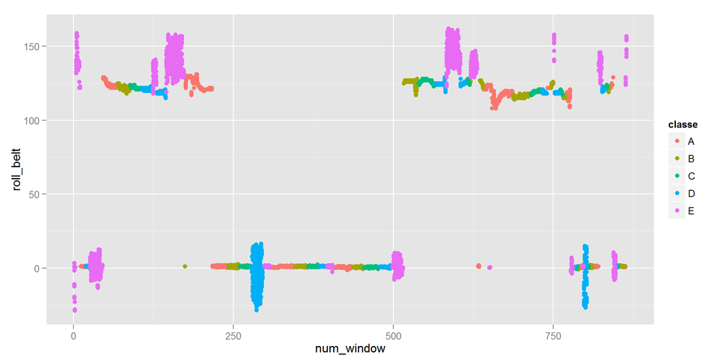

```r
qplot(num_window,roll_belt, colour = classe, data=training)
```

It is readily apparent why these two predictors are so valuable: the classe categories stand apart from each other in sharp relief when they are charted against one another, much more sharply than in any of the charts used in the lecture examples in class.

### Conclusions

We came to the exercise prepared to test a wide variety of models and methods to achieve high predictive accuracy, but the very first model we tried, with minimal, common-sense shaping of the data, provided a model sufficiently accurate for us to score 100% of the validation observations successfully, so we stopped the exercise and are submitting these findings.

### Appendices:

```r
str(training)
```

```
## 'data.frame':    11776 obs. of  55 variables:
##  $ new_window          : Factor w/ 2 levels "no","yes": 1 1 1 1 1 1 1 1 1 1 ...
##  $ num_window          : int  11 11 12 12 12 12 12 12 12 12 ...
##  $ roll_belt           : num  1.41 1.41 1.48 1.45 1.42 1.42 1.43 1.45 1.42 1.42 ...
##  $ pitch_belt          : num  8.07 8.07 8.05 8.06 8.09 8.13 8.16 8.17 8.2 8.21 ...
##  $ yaw_belt            : num  -94.4 -94.4 -94.4 -94.4 -94.4 -94.4 -94.4 -94.4 -94.4 -94.4 ...
##  $ total_accel_belt    : int  3 3 3 3 3 3 3 3 3 3 ...
##  $ gyros_belt_x        : num  0 0.02 0.02 0.02 0.02 0.02 0.02 0.03 0.02 0.02 ...
##  $ gyros_belt_y        : num  0 0 0 0 0 0 0 0 0 0 ...
##  $ gyros_belt_z        : num  -0.02 -0.02 -0.03 -0.02 -0.02 -0.02 -0.02 0 0 -0.02 ...
##  $ accel_belt_x        : int  -21 -22 -22 -21 -22 -22 -20 -21 -22 -22 ...
##  $ accel_belt_y        : int  4 4 3 4 3 4 2 4 4 4 ...
##  $ accel_belt_z        : int  22 22 21 21 21 21 24 22 21 21 ...
##  $ magnet_belt_x       : int  -3 -7 -6 0 -4 -2 1 -3 -3 -8 ...
##  $ magnet_belt_y       : int  599 608 604 603 599 603 602 609 606 598 ...
```

[output cut: 41 more lines]

```r
str(testing)
```

```
## 'data.frame':    7846 obs. of  55 variables:
##  $ new_window          : Factor w/ 2 levels "no","yes": 1 1 1 1 1 1 1 2 1 1 ...
##  $ num_window          : int  11 12 12 12 12 12 12 12 13 13 ...
##  $ roll_belt           : num  1.42 1.48 1.45 1.43 1.45 1.6 1.57 1.51 1.53 1.55 ...
##  $ pitch_belt          : num  8.07 8.07 8.18 8.18 8.2 8.1 8.09 8.1 8.11 8.09 ...
##  $ yaw_belt            : num  -94.4 -94.4 -94.4 -94.4 -94.4 -94.4 -94.4 -94.4 -94.4 -94.4 ...
##  $ total_accel_belt    : int  3 3 3 3 3 3 3 3 3 3 ...
##  $ gyros_belt_x        : num  0 0.02 0.03 0.02 0 0.02 0.02 0.02 0.03 0.02 ...
##  $ gyros_belt_y        : num  0 0.02 0 0 0 0 0.02 0 0 0 ...
##  $ gyros_belt_z        : num  -0.02 -0.02 -0.02 -0.02 0 -0.02 -0.02 -0.02 0 0 ...
##  $ accel_belt_x        : int  -20 -21 -21 -22 -21 -20 -21 -20 -19 -21 ...
##  $ accel_belt_y        : int  5 2 2 2 2 1 3 4 4 3 ...
##  $ accel_belt_z        : int  23 24 23 23 22 20 21 22 21 22 ...
##  $ magnet_belt_x       : int  -2 -6 -5 -2 -1 -10 -2 -3 -8 -10 ...
##  $ magnet_belt_y       : int  600 600 596 602 597 607 604 601 605 601 ...
```

[output cut: 41 more lines]

**Appendix B: Most important variables**

```r
varImp(modelFit)
```

```
##                          Overall
## new_window             0.2516382
## num_window           784.0601799
## roll_belt            676.6097922
## pitch_belt           386.2829537
## yaw_belt             490.7835957
## total_accel_belt     134.2823849
## gyros_belt_x          56.4245718
## gyros_belt_y          65.2271959
## gyros_belt_z         148.7312630
## accel_belt_x          78.9708627
## accel_belt_y          82.2910829
## accel_belt_z         226.7552584
## magnet_belt_x        142.2740178
## magnet_belt_y        225.9057524
## magnet_belt_z        210.1411144
## roll_arm             163.4476703
## pitch_arm             91.7096854
## yaw_arm              132.2619185
## total_accel_arm       52.8339413
## gyros_arm_x           67.1813856
## gyros_arm_y           69.3470300
## gyros_arm_z           33.3811012
## accel_arm_x          147.1252085
## accel_arm_y           87.1093353
## accel_arm_z           68.4709507
## magnet_arm_x         154.0587977
## magnet_arm_y         121.5419331
## magnet_arm_z          94.7496765
## roll_dumbbell        241.6096792
## pitch_dumbbell       105.0923925
## yaw_dumbbell         142.4985780
## total_accel_dumbbell 150.0295602
## gyros_dumbbell_x      65.7363648
## gyros_dumbbell_y     135.2524512
## gyros_dumbbell_z      44.2442844
## accel_dumbbell_x     150.7165580
## accel_dumbbell_y     224.7948669
## accel_dumbbell_z     181.7227110
## magnet_dumbbell_x    264.4034628
## magnet_dumbbell_y    383.7789072
## magnet_dumbbell_z    423.4861717
## roll_forearm         321.1014476
## pitch_forearm        429.8844336
## yaw_forearm           86.1076527
## total_accel_forearm   57.6339276
## gyros_forearm_x       38.3794336
## gyros_forearm_y       65.2728242
## gyros_forearm_z       47.6588945
## accel_forearm_x      173.2123645
## accel_forearm_y       74.9040305
## accel_forearm_z      134.2937348
## magnet_forearm_x     112.2064272
## magnet_forearm_y     120.6720759
## magnet_forearm_z     142.8156534
```